# ML2-Assignment2-Visualization

GroupA

10/7/2019

# 1. INTRODUCTION

This project explored the use of a variety of predictive/classification modeling techniques for purposes of predicting the functional status of water pumps located within the country of Tanzania on the basis of data provided via a www.DrivenData.org data challenge competition. Hand-driven and gravity fed water pumps are a key source of potable water throughout much of Africa and a smart understanding of which waterpoints will fail can improve maintenance operations and ensure that clean, potable water is available to communities across Tanzania. According to Tanzania’s Ministry of Water, more than 74,000 such pumps can be found throughout the country. While the installation of these pumps is largely funded via contributions from charitable and other non-governmental organizations (NGO’s), their ongoing maintenance is typically the responsibility of the local community within which they reside. Unfortunately, the cost of maintaining the pumps is often beyond the means of the local community, resulting in pumps becoming non-functional. Furthermore, local communities are often unaware of the need to perform the required maintenance due to the apparent lack of any significant problems with a pump up until the point it ultimately fails. In order to predict one of the three classes of the status of the pump (functional, non-functional, functional and needs repair) we will clean the data filling missing values, do the necessary feature engineering and feature selection to finally run the best models. We are working based on a number of independent variables about when and where it was installed, the kind of operation and how it is managed.

Load packages and datasets.

```r
knitr::opts_chunk$set(echo = TRUE)

library(Metrics)
library(readr)
library(ggplot2)
library(e1071)
library(glmnet)
library(caret)
library(FSelector)
library(dplyr)
library(stats)
library(purrr)
library(tidyr)
library(questionr)
library(doMC)
library(maptree)
library(corrplot)
library(data.table)
library(scales)
library(MASS)
library(rpart)
library(rpart.plot)
library(nnet)
library(skimr)
library(gbm)
library(grDevices)
library(leaps)
library(mlbench)
library(mltools)
library(GoodmanKruskal)
library(randomForest)
library(xgboost)

predict_values = read.csv(file = file.path('Pump_it_Up_Data_Mining_the_Water_Table_-_Test_set_values.csv'),  header = TRUE, dec = ".", sep = ",")
train_values = read.csv(file = file.path('Pump_it_Up_Data_Mining_the_Water_Table_-_Training_set_values.csv'),  header = TRUE, dec = ".", sep = ",")
train_labels = read.csv(file = file.path('Pump_it_Up_Data_Mining_the_Water_Table_-_Training_set_labels.csv'),  header = TRUE, dec = ".", sep = ",")
predict_labels = read.csv(file = file.path('Pump_it_Up_Data_Mining_the_Water_Table_-_Submission_format.csv'),  header = TRUE, dec = ".", sep = ",")
```

Combine datasets. join by id and stack on df for transformations. The dataset is already devided in train and test (in our case called predict)

```r
train <- left_join(train_values, train_labels) # joining by id
predict <- left_join(predict_values, predict_labels) # joining by id
df <- rbind(train, predict)
```

# 2. Exploratory Data Analysis

During this section, we will work only on the train dataset.

## 2.1 Quick look at the dataset

Get a look at the dataset using skimmed and str. Investigation of the characteristics of each individual variable contained within the train data set, including their data types, range of valid values, their distributions, and missing data values.

```r
skimmed <- skim_to_wide(train)
```

```r
skimmed[,c(1:3,5:6,9,10,16)]
```

```
## # A tibble: 41 x 8
##    type   variable              missing n     n_unique mean  sd    hist
##    <chr>  <chr>                 <chr>   <chr> <chr>    <chr> <chr> <chr>
##  1 factor basin                 0       59400 9        <NA>  <NA>  <NA>
##  2 factor date_recorded         0       59400 356      <NA>  <NA>  <NA>
##  3 factor extraction_type       0       59400 18       <NA>  <NA>  <NA>
##  4 factor extraction_type_class 0       59400 7        <NA>  <NA>  <NA>
##  5 factor extraction_type_group 0       59400 13       <NA>  <NA>  <NA>
##  6 factor funder                0       59400 1898     <NA>  <NA>  <NA>
##  7 factor installer             0       59400 2146     <NA>  <NA>  <NA>
##  8 factor lga                   0       59400 125      <NA>  <NA>  <NA>
##  9 factor management            0       59400 12       <NA>  <NA>  <NA>
## 10 factor management_group      0       59400 5        <NA>  <NA>  <NA>
## # … with 31 more rows
```

```r
str(train)
```

```
## 'data.frame':    59400 obs. of  41 variables:
##  $ id                   : int  69572 8776 34310 67743 19728 9944 19816 54551 53934 46144 ...
##  $ amount_tsh           : num  6000 0 25 0 0 20 0 0 0 0 ...
##  $ date_recorded        : Factor w/ 356 levels "2002-10-14","2004-01-07",..: 48 310 301 273 105 47 187 195 220 126 ...
##  $ funder               : Factor w/ 1898 levels "","0","A/co Germany",..: 1371 471 827 1743 22 987 347 1418 1844 595 ...
##  $ gps_height           : int  1390 1399 686 263 0 0 0 0 0 0 ...
##  $ installer            : Factor w/ 2146 levels "","-","0","A.D.B",..: 1557 593 2115 1927 119 435 446 435 2045 119 ...
##  $ longitude            : num  34.9 34.7 37.5 38.5 31.1 ...
##  $ latitude             : num  -9.86 -2.15 -3.82 -11.16 -1.83 ...
##  $ wpt_name             : Factor w/ 37400 levels "24","A Kulwa",..: 32437 37197 14573 37287 35531 36139 20673 36485 21732 25773 ...
##  $ num_private          : int  0 0 0 0 0 0 0 0 0 0 ...
##  $ basin                : Factor w/ 9 levels "Internal","Lake Nyasa",..: 2 5 6 8 5 6 1 4 4 5 ...
##  $ subvillage           : Factor w/ 19288 levels "","'A' Kati",..: 11809 15840 9076 8984 7700 11813 3798 16345 3438 11445 ...
##  $ region               : Factor w/ 21 levels "Arusha","Dar es Salaam",..: 4 10 9 13 5 21 18 18 20 5 ...
##  $ region_code          : int  11 20 21 90 18 4 17 17 14 18 ...
```

[output cut: 27 more lines]

```r
summary(train)
```

```
##        id          amount_tsh          date_recorded
##  Min.   :    0   Min.   :     0.0   2011-03-15:  572
##  1st Qu.:18520   1st Qu.:     0.0   2011-03-17:  558
##  Median :37062   Median :     0.0   2013-02-03:  546
##  Mean   :37115   Mean   :   317.7   2011-03-14:  520
##  3rd Qu.:55656   3rd Qu.:    20.0   2011-03-16:  513
##  Max.   :74247   Max.   :350000.0   2011-03-18:  497
##                                     (Other)   :56194
##                     funder        gps_height          installer
##  Government Of Tanzania: 9084   Min.   : -90.0   DWE       :17402
##                        : 3635   1st Qu.:   0.0             : 3655
##  Danida                : 3114   Median : 369.0   Government: 1825
##  Hesawa                : 2202   Mean   : 668.3   RWE       : 1206
##  Rwssp                 : 1374   3rd Qu.:1319.2   Commu     : 1060
##  World Bank            : 1349   Max.   :2770.0   DANIDA    : 1050
##  (Other)               :38642                    (Other)   :33202
##    longitude        latitude            wpt_name      num_private
##  Min.   : 0.00   Min.   :-11.649   none     : 3563   Min.   :   0.0000
##  1st Qu.:33.09   1st Qu.: -8.541   Shuleni  : 1748   1st Qu.:   0.0000
##  Median :34.91   Median : -5.022   Zahanati :  830   Median :   0.0000
##  Mean   :34.08   Mean   : -5.706   Msikitini:  535   Mean   :   0.4741
##  3rd Qu.:37.18   3rd Qu.: -3.326   Kanisani :  323   3rd Qu.:   0.0000
##  Max.   :40.35   Max.   :  0.000   Bombani  :  271   Max.   :1776.0000
##                                    (Other)  :52130
##              basin          subvillage            region
##  Lake Victoria  :10248   Madukani:  508   Iringa     : 5294
##  Pangani        : 8940   Shuleni :  506   Shinyanga  : 4982
##  Rufiji         : 7976   Majengo :  502   Mbeya      : 4639
##  Internal       : 7785   Kati    :  373   Kilimanjaro: 4379
##  Lake Tanganyika: 6432           :  371   Morogoro   : 4006
##  Wami / Ruvu    : 5987   Mtakuja :  262   Arusha     : 3350
##  (Other)        :12032   (Other) :56878   (Other)    :32750
##   region_code   district_code             lga               ward
##  Min.   : 1.0   Min.   : 0.00   Njombe      : 2503   Igosi    :  307
##  1st Qu.: 5.0   1st Qu.: 2.00   Arusha Rural: 1252   Imalinyi :  252
##  Median :12.0   Median : 3.00   Moshi Rural : 1251   Siha Kati:  232
##  Mean   :15.3   Mean   : 5.63   Bariadi     : 1177   Mdandu   :  231
##  3rd Qu.:17.0   3rd Qu.: 5.00   Rungwe      : 1106   Nduruma  :  217
##  Max.   :99.0   Max.   :80.00   Kilosa      : 1094   Kitunda  :  203
##                                 (Other)     :51017   (Other)  :57958
```

[output cut: 57 more lines]

```
##  groundwater:45794   cattle trough              :  116
##  surface    :13328   communal standpipe         :28522
##  unknown    :  278   communal standpipe multiple: 6103
##                      dam                        :    7
##                      hand pump                  :17488
##                      improved spring            :  784
##                      other                      : 6380
##         waterpoint_type_group                  status_group
##  cattle trough     :  116     functional             :32259
##  communal standpipe:34625     functional needs repair: 4317
##  dam               :    7     non functional         :22824
##  hand pump         :17488
##  improved spring   :  784
##  other             : 6380
##
```

Multiple factor varibales are included and some of them with high number of levels. from histograms we see some values with 0s

## 2.2 Distribution of the label (status_group)

Dependent variable to predict.

```r
# absolute numbers
table(train$status_group)
```

```
##
##              functional functional needs repair          non functional
##                   32259                    4317                   22824
```

```r
# proportions
prop.table(table(train$status_group))
```

```
##
##              functional functional needs repair          non functional
##              0.54308081              0.07267677              0.38424242
```

Dependent variable distribution (waterpump status): 54.30% of the pumps are functional 7.27% are functional but needs repairs 38.43% are non functional

There is a low number of pumps functional but need repair. other than that, the data is well balanced. This may make it difficult to predict accurately the functional needs repair pumps with linear or tree models.

## 2.6 Unique values

We observe factors with high number of unique values (levels) that will need to be treated before introducing in the model.

```r
unique_values<- function(x){
return(length(unique(x)));
}
unique <- sapply(train, unique_values)
unique[order(unique)]
```

```
##           recorded_by        public_meeting                permit
##                     1                     3                     3
##          source_class          status_group      management_group
##                     3                     3                     5
##              quantity        quantity_group         quality_group
##                     5                     5                     6
## waterpoint_type_group extraction_type_class               payment
##                     6                     7                     7
##          payment_type           source_type       waterpoint_type
##                     7                     7                     7
##         water_quality                 basin                source
##                     8                     9                    10
##            management     scheme_management extraction_type_group
##                    12                    13                    13
##       extraction_type         district_code                region
##                    18                    20                    21
##           region_code     construction_year           num_private
##                    27                    55                    65
##            amount_tsh                   lga         date_recorded
##                    98                   125                   356
##            population                funder                  ward
##                  1049                  1898                  2092
##             installer            gps_height           scheme_name
##                  2146                  2428                  2697
##            subvillage              wpt_name             longitude
##                 19288                 37400                 57516
##              latitude                    id
##                 57517                 59400
```

## 2.7 Missing values (NAs)

No NAs but we will see on future analysis there are some empty spaces and invalid values (0s) in both continuous and categorical features.

```r
missing <- sapply(train, function(x){sum(is.na(x))})
missing[order(missing, decreasing = TRUE)]
```

```
##                    id            amount_tsh         date_recorded
##                     0                     0                     0
##                funder            gps_height             installer
##                     0                     0                     0
##             longitude              latitude              wpt_name
##                     0                     0                     0
##           num_private                 basin            subvillage
##                     0                     0                     0
##                region           region_code         district_code
##                     0                     0                     0
##                   lga                  ward            population
##                     0                     0                     0
##        public_meeting           recorded_by     scheme_management
##                     0                     0                     0
##           scheme_name                permit     construction_year
##                     0                     0                     0
##       extraction_type extraction_type_group extraction_type_class
##                     0                     0                     0
##            management      management_group               payment
##                     0                     0                     0
##          payment_type         water_quality         quality_group
##                     0                     0                     0
##              quantity        quantity_group                source
##                     0                     0                     0
##           source_type          source_class       waterpoint_type
##                     0                     0                     0
## waterpoint_type_group          status_group
##                     0                     0
```

## 2.3 Analyze some categorical values with not high number of factors.

Using a quick frecuency table we can evalaute if independent variables are unbalanced. We will see if there is any high level relationship between independent variables (for example: quantity and quantity_group) and their relation with the target.

# Payment:

those wp paying has higher percentage of functional while with the not paying the distribution is similar.

```r
# absolute numbers
table(train$payment, train$status_group)
```

```
##
##                         functional functional needs repair non functional
##   never pay                  11379                    1907          12062
##   other                        611                     118            325
##   pay annually                2740                     247            655
##   pay monthly                 5482                     927           1891
##   pay per bucket              6090                     409           2486
##   pay when scheme fails       2429                     277           1208
##   unknown                     3528                     432           4197
```

```r
# proportions
prop.table(table(train$payment, train$status_group), margin = 1)
```

```
##
##                         functional functional needs repair non functional
##   never pay             0.44891116              0.07523276     0.47585608
##   other                 0.57969639              0.11195446     0.30834915
##   pay annually          0.75233388              0.06781988     0.17984624
##   pay monthly           0.66048193              0.11168675     0.22783133
##   pay per bucket        0.67779633              0.04552031     0.27668336
##   pay when scheme fails 0.62059274              0.07077159     0.30863567
##   unknown               0.43251195              0.05296065     0.51452740
```

We can observe that on those cases where users pays for the service (on any way) the average of functional is significantly higher than in those cases where users are not paying.

# Quantity

Table of the quantity variable vs the status of the pumps

```r
table(train$quantity, train$quantity_group) # mirror
```

```
##
##                  dry enough insufficient seasonal unknown
##   dry           6246      0            0        0       0
##   enough           0  33186            0        0       0
##   insufficient     0      0        15129        0       0
##   seasonal         0      0            0     4050       0
##   unknown          0      0            0        0     789
```

```r
table(train$quantity, train$status_group)
```

```
##
##                functional functional needs repair non functional
##   dry                 157                      37           6052
##   enough            21648                    2400           9138
##   insufficient       7916                    1450           5763
##   seasonal           2325                     416           1309
##   unknown             213                      14            562
```

# Public_meeting

see if it is an useful variable to consider

```r
freq(train$public_meeting)
```

```
##           n    % val%
##        3334  5.6  5.6
## False  5055  8.5  8.5
## True  51011 85.9 85.9
```

```r
prop.table(table(train$public_meeting, train$status_group), margin = 1)
```

```
##
##         functional functional needs repair non functional
##         0.50329934              0.04679064     0.44991002
##   False 0.42987141              0.08743818     0.48269041
##   True  0.55689949              0.07290584     0.37019466
```

While 85% of the values are TRUE, on the FALSE (8%) values we see a higher proportion of non functioning wells. highly unbalanced feature

# Num_private

98.7% of the values are 0! doesnt seem to be a very useful variable.

```r
freq(train$num_private)
```

```
##          n    % val%
## 0    58643 98.7 98.7
## 1       73  0.1  0.1
## 2       23  0.0  0.0
## 3       27  0.0  0.0
## 4       20  0.0  0.0
## 5       46  0.1  0.1
## 6       81  0.1  0.1
## 7       26  0.0  0.0
## 8       46  0.1  0.1
## 9        4  0.0  0.0
## 10       4  0.0  0.0
## 11      11  0.0  0.0
## 12       5  0.0  0.0
## 14       3  0.0  0.0
```

[output cut: 51 more lines]

```r
num_priv_table <- table(train$num_private, train$status_group)
num_priv_table_prop <- prop.table(table(train$num_private, train$status_group), margin = 1)
```

The widespread incidence of missing data throughout the data set was a strong indicator of the need for the development of statistically valid data imputation algorithms for many of the affected variables. For this we will start analyzing the correlation between independent variables in order to maximize the accuracy of our imputations.

# 2.4 Correlation Matrix (numerical values)

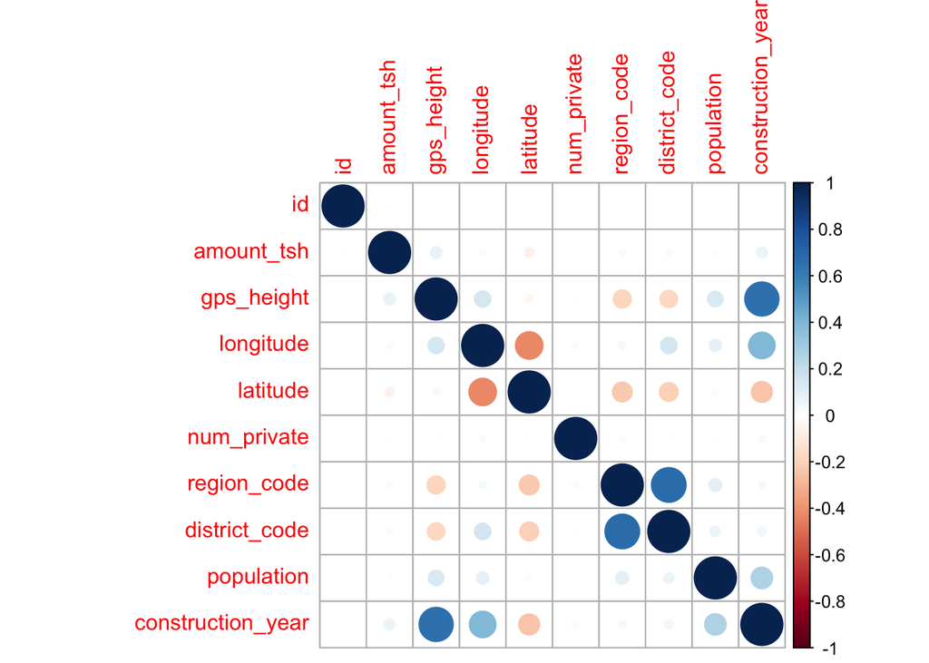

```r
nums <- sapply(train, is.numeric)
data.numeric <- train[ ,c(nums)]
data.without_na <- na.omit(data.numeric)
cor_matrix <- cor(data.without_na)
corrplot(cor_matrix)
```

```r
findCorrelation(cor_matrix, 0.7)
```

```
## integer(0)
```

## 2.5 Correlation matrix within factors

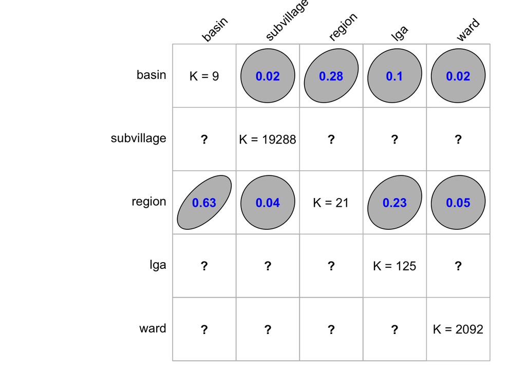

```r
train_region <- train[,(names(train) %in% c("latitude", "longitude", 'gps_height', 'region', 'basin', 'subvillage', 'region','region_code','district_code','lga','ward'))]

factors <- sapply(train_region, is.factor)
data.factor <- train_region[1:500,c(factors)]
gkmatrix <- GKtauDataframe(data.factor)
plot(gkmatrix, corrColors = 'blue')
```

## 2.6 ChiSquare test

Objective: find correlation between independent and categorical variables. With the aim of simplifying the model, we need to reduce the number of variables as much as possible.

We will identify any corelation between independent features runing a chi-square test: Ho: Variables are independent Ha: Variables are dependent As p-value < 0.05 we can reject the null hypotesis in favor of Ha and conclude that the variables are dependent to each other and we will keep only 1 to run the models.

```r
chisq.test(train$quantity, train$quality_group, correct = FALSE)
```

```
##
##  Pearson's Chi-squared test
##
## data:  train$quantity and train$quality_group
## X-squared = 18574, df = 20, p-value < 2.2e-16
```

```r
chisq.test(train$management_group, train$scheme_management, correct = FALSE)
```

```
##
##  Pearson's Chi-squared test
##
## data:  train$management_group and train$scheme_management
## X-squared = 114210, df = 48, p-value < 2.2e-16
```

```r
chisq.test(train$extraction_type, train$source, correct = FALSE)
```

```
##
##  Pearson's Chi-squared test
##
## data:  train$extraction_type and train$source
## X-squared = 88948, df = 153, p-value < 2.2e-16
```

```r
chisq.test(train$source, train$waterpoint_type_group, correct = FALSE)
```

```
##
##  Pearson's Chi-squared test
##
## data:  train$source and train$waterpoint_type_group
## X-squared = 43953, df = 45, p-value < 2.2e-16
```

# 3. Visualization

## 3.1 Continuous variables:

latitude, longitude, construction_year, amount_tsh, population

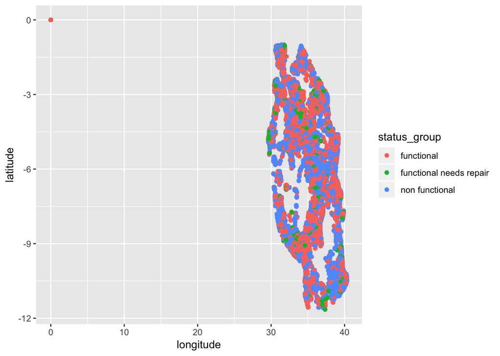

```r
ggplot(data=train, aes(x=longitude, y=latitude, color = status_group)) + geom_point()
```

No clear geographical association with the status of the wells. values at (0,0) needs to be treated. Other than (0,0), all values within Tanzania limits.

# Histograms

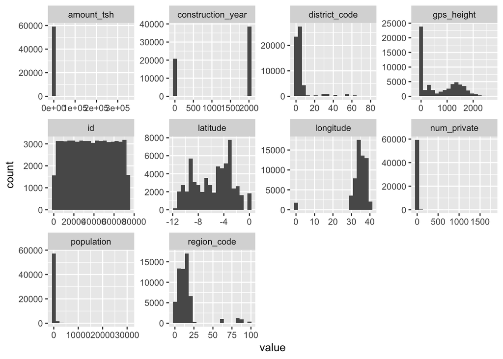

```r
train %>%
  keep(is.numeric) %>%
  gather() %>%
  ggplot(aes(x = value)) +
  facet_wrap(~ key, scales = "free") +
  geom_histogram(bins = 20)
```

```r
# we wont consider district_code, region_code and num_private at this stage.
```

# amount_tsh

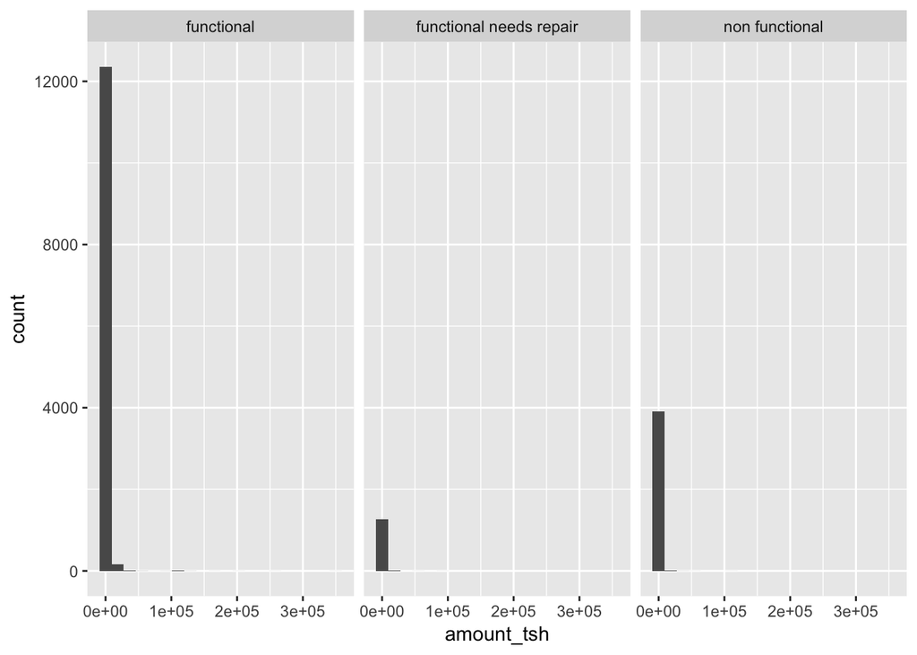

```r
ggplot(subset(train, amount_tsh > 0), aes(x = amount_tsh)) +
  geom_histogram(bins = 20) +
  facet_grid( ~ status_group)
```

# gps_height

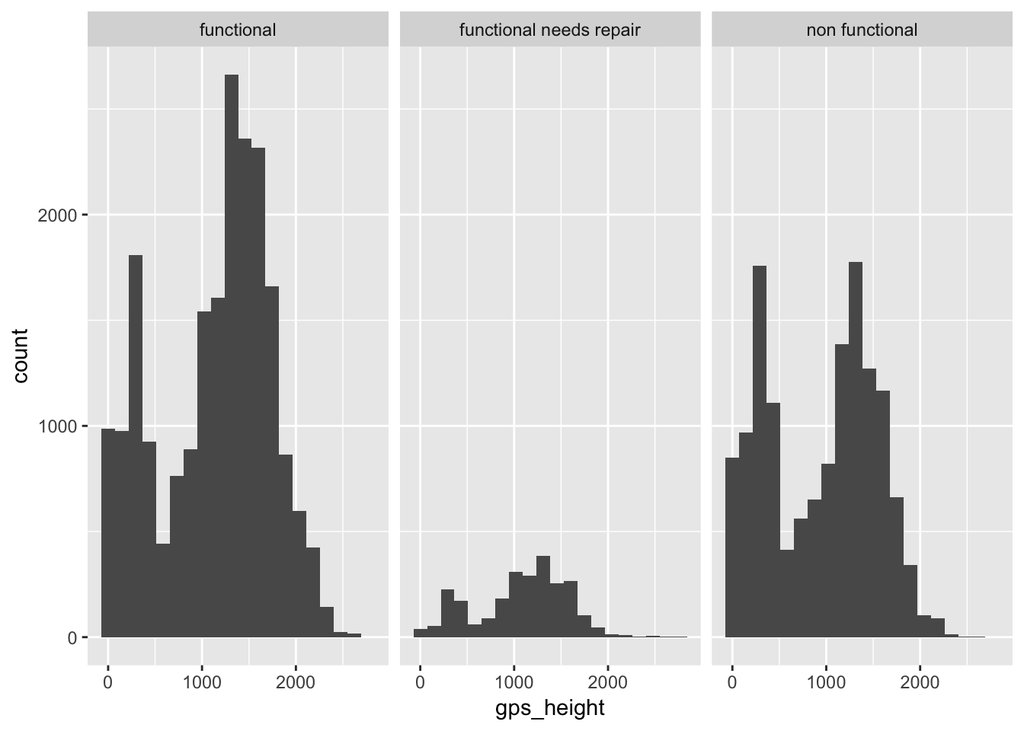

```r
ggplot(subset(train, gps_height > 0), aes(x = gps_height)) +
  geom_histogram(bins = 20) +
  facet_grid( ~ status_group)
```

# Construction year > 0

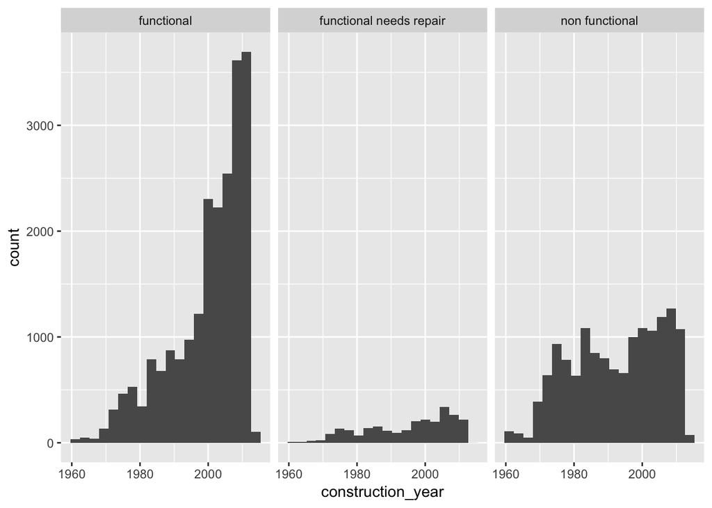

```r
ggplot(subset(train, construction_year > 0), aes(x = construction_year)) +
  geom_histogram(bins = 20) +
  facet_grid( ~ status_group)
```

# Population

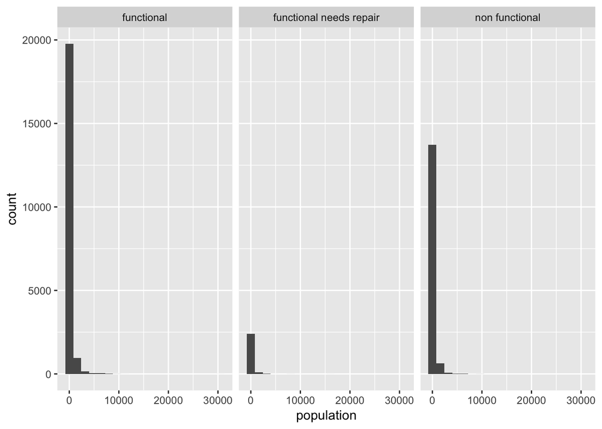

```r
ggplot(subset(train, population > 0), aes(x = population)) +
  geom_histogram(bins = 20) +
  facet_grid( ~ status_group)
```

We visualize the impact of each independent feature on the labels before any transformation - only for numeric variables.

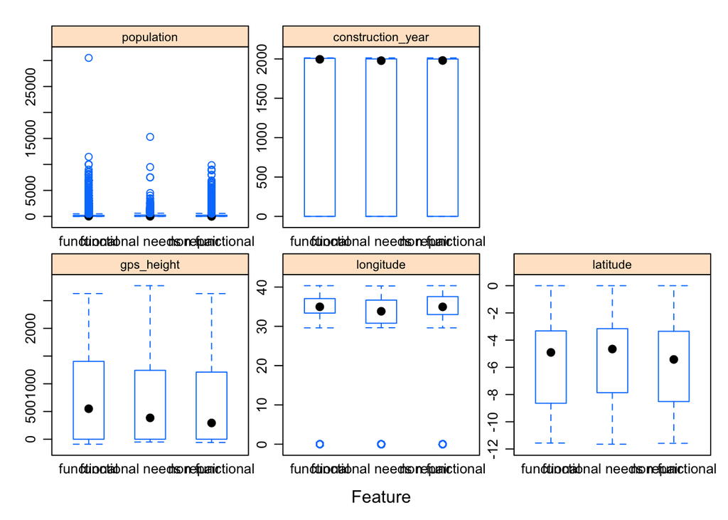

```r
featurePlot(x=train[,c(5,7,8,18,24)], y=train$status_group, plot = 'box', strip = strip.custom(par.strip.text=list(cex=.7)), scales = list(x = list(relation = 'free'), y = list(relation='free')))
```

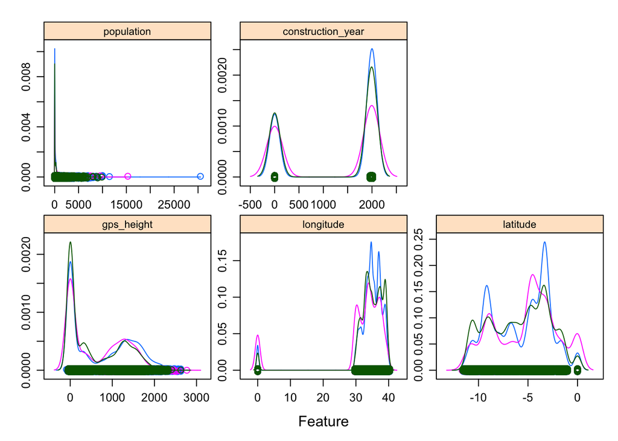

```r
featurePlot(x=train[,c(5,7,8,18,24)], y=train$status_group, plot = 'density', strip = strip.custom(par.strip.text=list(cex=.7)), scales = list(x = list(relation = 'free'), y = list(relation='free')))
```

## 3.2 Barplots for factors.

# Quantity

5 levels. points with enough quantity has higher porcentage of function than others

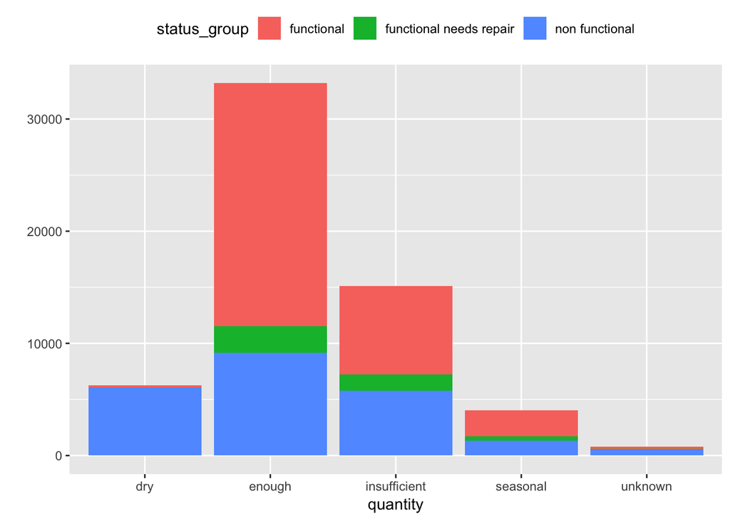

```r
qplot(quantity, data=train, geom="bar", fill=status_group) +
  theme(legend.position = "top")
```

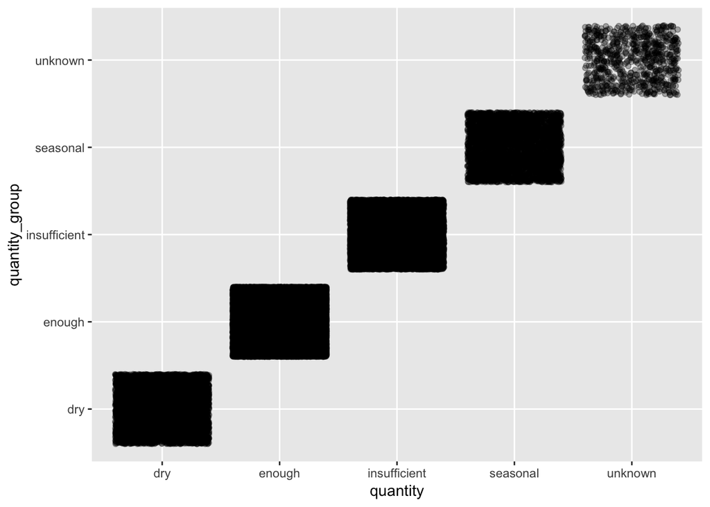

```r
ggplot(train, aes(x=quantity, y=quantity_group,)) +
  geom_jitter(alpha = 0.3)
```

# quality_group

high percent with quality = good (around 90%)

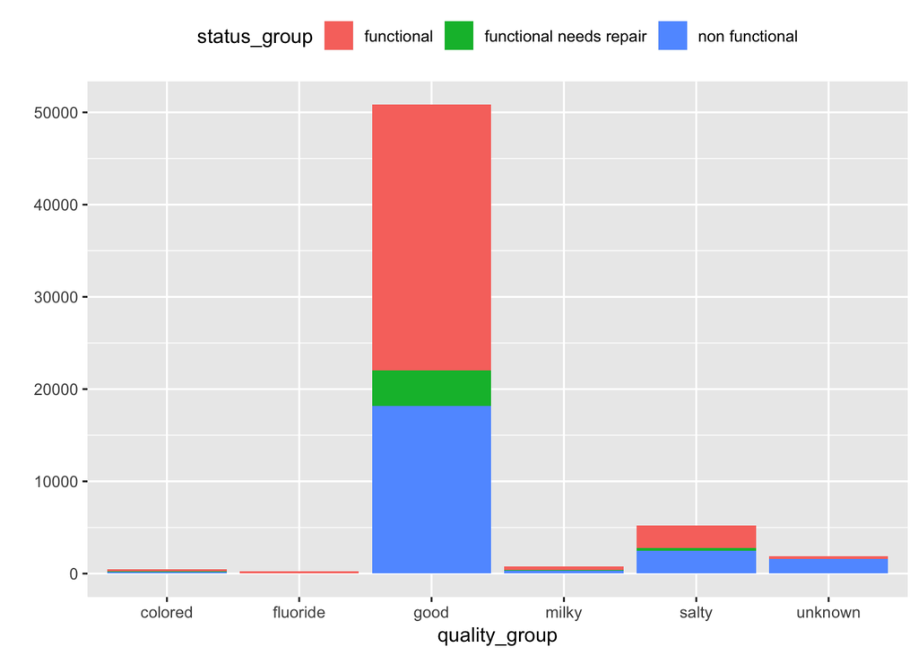

```r
qplot(quality_group, data=train, geom="bar", fill=status_group) +
  theme(legend.position = "top")
```

# waterpoint_type

hand pump with higher percent of working than avg.

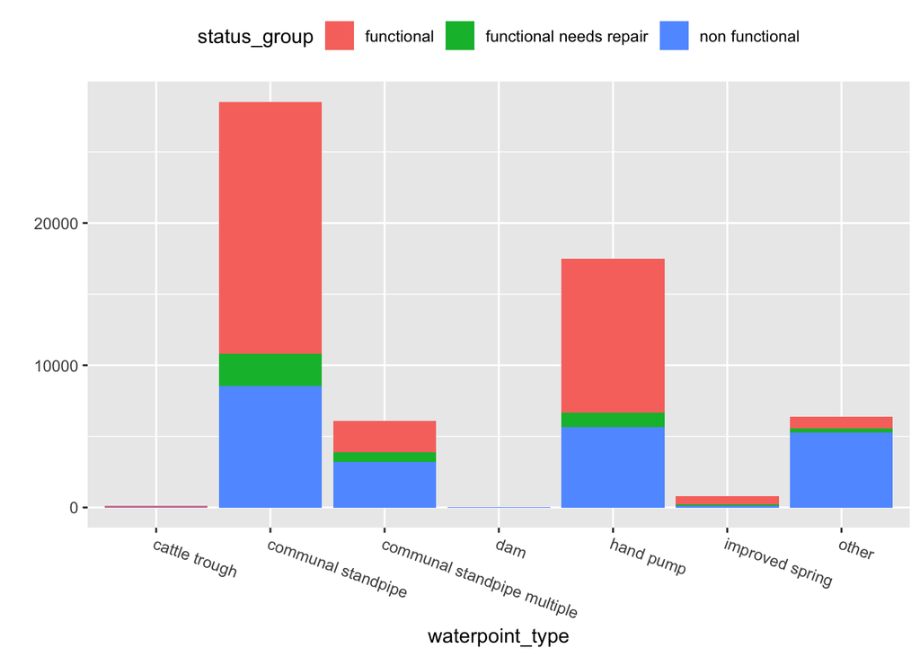

```r
qplot(waterpoint_type, data=train, geom="bar", fill=status_group) +
  theme(legend.position = "top") +
  theme(axis.text.x=element_text(angle = -20, hjust = 0))
```

# payment

those paying has a better behaviour.

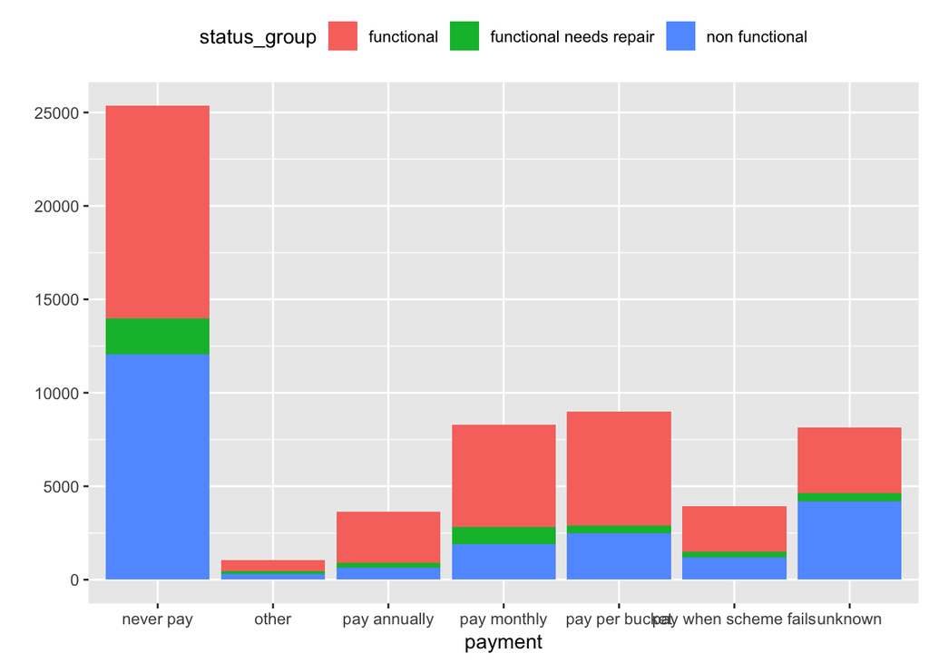

```r
qplot(payment, data=train, geom="bar", fill=status_group) +
  theme(legend.position = "top")
```